# Linear Regression With a Categorical Exposure Variable

Abdirasak

2024-11-07

# 1 Lung transplant data

For lung transplantation it is ideal for the donor’s lungs to be of a similar size to those of the recipient. Total lung capacity (TLC) is difficult to measure, so it is useful to be able to predict TLC from other information. These data are pre-transplantation TLC of 32 recipients of heart-lung transplants, obtained by whole-body plethysmography.

Variables: - Age : Measured in years - sex : 1 = male; 2 = female - Height : measured in cm - TLC : Total lung capacity (litres)

```r
library("tidyverse")
lung <- read.csv("lung.csv")
table(View(head(lung)))
```

```
## < table of extent 0 >
```

```r
str(lung)
```

```
## 'data.frame':    32 obs. of  5 variables:
##  $ id    : int  1 2 3 4 5 6 7 8 9 10 ...
##  $ age   : int  35 11 12 16 32 16 14 16 35 33 ...
##  $ sex   : int  2 2 1 2 2 2 2 1 2 2 ...
##  $ height: int  149 138 148 156 152 157 165 152 177 158 ...
##  $ tlc   : num  3.4 3.41 3.8 3.9 4 ...
```

```r
#Descriptive statistics
summary(lung) # simple descriptive statistic
```

```
##        id             age             sex          height           tlc
##  Min.   : 1.00   Min.   :11.00   Min.   :1.0   Min.   :138.0   Min.   :3.400
##  1st Qu.: 8.75   1st Qu.:20.75   1st Qu.:1.0   1st Qu.:159.5   1st Qu.:4.760
##  Median :16.50   Median :28.50   Median :1.5   Median :170.0   Median :6.150
##  Mean   :16.50   Mean   :28.41   Mean   :1.5   Mean   :167.4   Mean   :6.088
##  3rd Qu.:24.25   3rd Qu.:35.00   3rd Qu.:2.0   3rd Qu.:175.5   3rd Qu.:7.225
##  Max.   :32.00   Max.   :52.00   Max.   :2.0   Max.   :189.0   Max.   :9.450
```

```r
table(lung$sex)
```

```
##
##  1  2
## 16 16
```

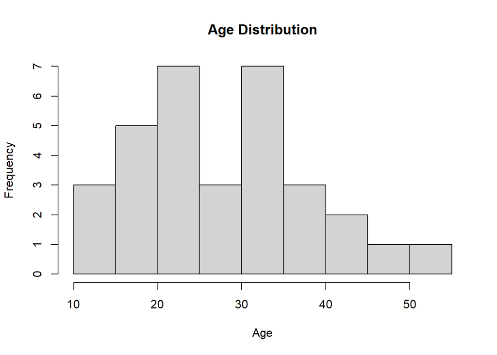

```r
hist(lung$age, main = "Age Distribution", xlab = "Age")
```

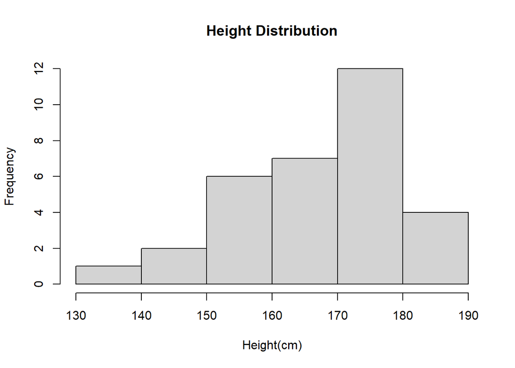

```r
hist(lung$height, main = "Height Distribution", xlab = "Height(cm)")
```

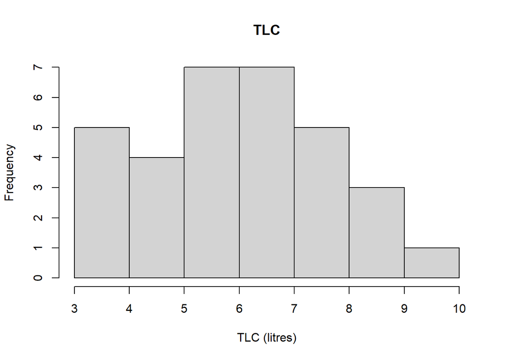

```r
hist(lung$tlc, main = "TLC", xlab = "TLC (litres)")
```

#Formatting data

```r
table(lung$sex) #the variable sex is currently stored as 1, and 2
```

```
##
##  1  2
## 16 16
```

```r
str(lung$sex) #the sex variable is currently stored as an integer
```

```
##  int [1:32] 2 2 1 2 2 2 2 1 2 2 ...
```

```r
lung$sexfactor <- factor(lung$sex, levels = c(1,2), labels = c("male", "female"))

head(lung) # sex is now a categorical variable
```

|  | id | age | sex | height | tlc | sexfactor |
| --- | --- | --- | --- | --- | --- | --- |
| 1 | 1 | 35 | 2 | 149 | 3.40 | female |
| 2 | 2 | 11 | 2 | 138 | 3.41 | female |
| 3 | 3 | 12 | 1 | 148 | 3.80 | male |
| 4 | 4 | 16 | 2 | 156 | 3.90 | female |
| 5 | 5 | 32 | 2 | 152 | 4.00 | female |
| 6 | 6 | 16 | 2 | 157 | 4.10 | female |

```r
table(lung$sexfactor) # the label seems just about right.
```

```
##
##   male female
##     16     16
```

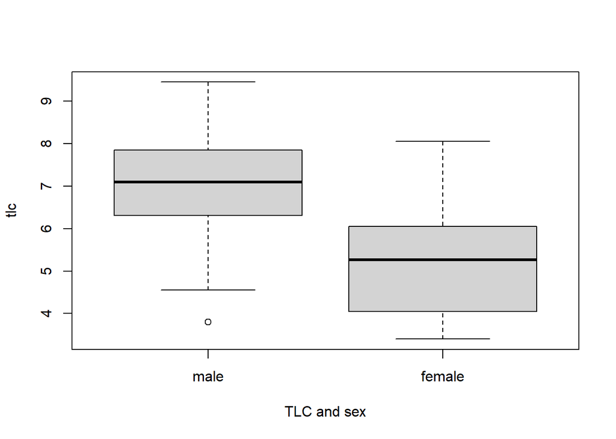

```r
boxplot(tlc~sexfactor, lung, xlab = "TLC and sex")
```

```r
summary(lung$tlc)
```

```
##    Min. 1st Qu.  Median    Mean 3rd Qu.    Max.
##   3.400   4.760   6.150   6.088   7.225   9.450
```

```r
# lets do some descriptive statistics

lung%>%
  select(tlc, sexfactor) %>%
  filter(sexfactor=="male") %>%
  summary()
```

```
##       tlc         sexfactor
##  Min.   :3.800   male  :16
##  1st Qu.:6.465   female: 0
##  Median :7.100
##  Mean   :6.977
##  3rd Qu.:7.825
##  Max.   :9.450
```

```r
lung%>%
  select(tlc, sexfactor) %>%
  filter(sexfactor=="female") %>%
  summary()
```

```
##       tlc         sexfactor
##  Min.   :3.400   male  : 0
##  1st Qu.:4.075   female:16
##  Median :5.270
##  Mean   :5.198
##  3rd Qu.:5.925
##  Max.   :8.050
```

## 1.1 Special note

I am gonna assume that the data doesnt meets the model assumptions

# 2 Regression

```r
simreg <- lm(tlc~sexfactor, lung)
summary(simreg)
```

```
##
## Call:
## lm(formula = tlc ~ sexfactor, data = lung)
##
## Residuals:
##     Min      1Q  Median      3Q     Max
## -3.1769 -1.0072  0.1231  0.8481  2.8519
##
## Coefficients:
##                 Estimate Std. Error t value Pr(>|t|)
## (Intercept)       6.9769     0.3428  20.354  < 2e-16 ***
## sexfactorfemale  -1.7787     0.4848  -3.669 0.000939 ***
## ---
## Signif. codes:  0 '***' 0.001 '**' 0.01 '*' 0.05 '.' 0.1 ' ' 1
##
## Residual standard error: 1.371 on 30 degrees of freedom
## Multiple R-squared:  0.3098, Adjusted R-squared:  0.2868
## F-statistic: 13.46 on 1 and 30 DF,  p-value: 0.0009392
```

```r
lung$sexfactor2 <- relevel(lung$sexfactor, "female")
# The reference can be changed, if we need females to be the reference

simreg2 <- lm(tlc~sexfactor2, lung)
summary(simreg2)
```

```
##
## Call:
## lm(formula = tlc ~ sexfactor2, data = lung)
##
## Residuals:
##     Min      1Q  Median      3Q     Max
## -3.1769 -1.0072  0.1231  0.8481  2.8519
##
## Coefficients:
##                Estimate Std. Error t value Pr(>|t|)
## (Intercept)      5.1981     0.3428  15.164 1.31e-15 ***
## sexfactor2male   1.7787     0.4848   3.669 0.000939 ***
## ---
## Signif. codes:  0 '***' 0.001 '**' 0.01 '*' 0.05 '.' 0.1 ' ' 1
##
## Residual standard error: 1.371 on 30 degrees of freedom
## Multiple R-squared:  0.3098, Adjusted R-squared:  0.2868
## F-statistic: 13.46 on 1 and 30 DF,  p-value: 0.0009392
```

```r
# Out interpretation remains the same, regardless
```

# 3 Interpretation

The linear regression model shows that the average TLC for males is 6.9769, while females have an average TLC that is 1.7787 units lower, estimated at 5.1982. This difference is statistically significant (p = 0.000939). This particular model explains 30.98% of the variation in TLC (adjusted R-squared = 0.2868). The overall model is statistically significant ( p-value of 0.0009392), indicating “sex” is a segnificant predictor of TLC.

# 4 Multiple linear regression

```r
multreg <- lm(tlc~sexfactor+height,lung)
summary(multreg)
```

```
##
## Call:
## lm(formula = tlc ~ sexfactor + height, data = lung)
##
## Residuals:
##      Min       1Q   Median       3Q      Max
## -1.59946 -0.84861 -0.03688  0.61923  2.76155
##
## Coefficients:
##                 Estimate Std. Error t value Pr(>|t|)
## (Intercept)     -6.26357    3.67984  -1.702  0.09943 .
## sexfactorfemale -0.77086    0.49571  -1.555  0.13078
## height           0.07607    0.02108   3.609  0.00114 **
## ---
## Signif. codes:  0 '***' 0.001 '**' 0.01 '*' 0.05 '.' 0.1 ' ' 1
##
## Residual standard error: 1.158 on 29 degrees of freedom
## Multiple R-squared:  0.5237, Adjusted R-squared:  0.4909
## F-statistic: 15.94 on 2 and 29 DF,  p-value: 2.133e-05
```

# 5 Interpretation

The multiple regression model shows that height is also a strong positive predictor of TLC: each additional unit of height(cm) increases TLC by 0.07607 units, statistically significant (p = 0.00114). After adjusting for height, females have a TLC that is 0.77086 units lower than males, but this difference is not statistically significant (p = 0.13078). The model, in general, explains 52.37% of the variation in TLC, improving substantially over the sex-only model. The residuals are also reasonably small (residual standard error 1.158), indicating a better fit than the simpler model.